# LinkedIn

Razmig Zeitounian

7/23/2021

Data Source: https://www.kaggle.com/killbot/linkedin-profiles-and-jobs-data

```r
library(tidyverse)
library(ISLR)
library(e1071)
library(knitr)

df <- read_csv("LinkedIn.csv") %>%
  # drop ID column
  select(-X1)

# we will treat country as a factor (rather than as a character) since it is a variable with one level (au)
df$country <- as.factor(df$country)
# treat isPremium as a factor (0 = No, 1 = Yes)?
df$isPremium <- as.factor(df$isPremium)
```

We show a quick preview of our data to make the data easier to understand.

```r
head(df, 10)
```

```
## # A tibble: 10 x 27
##    ageEstimate companyFollowerC~ companyHasLogo     companyName companyStaffCou~
##          <dbl>             <dbl> <chr>              <chr>                  <dbl>
##  1          41            198859 5a92c12e-0a20-482~ Commonweal~            32905
##  2          41            198859 5a92c12e-0a20-482~ Commonweal~            32905
##  3          41             10047 b1c3fd9a-8f21-48f~ CommSec                  619
##  4          41            198859 5a92c12e-0a20-482~ Commonweal~            32905
##  5          30            300723 0f982557-a907-409~ PayPal                 22522
##  6          30             71403 b976d16b-b41f-401~ Optus                  10913
##  7          30           4385293 e8d29e8b-1601-462~ IBM                   568533
##  8          30           4385293 e8d29e8b-1601-462~ IBM                   568533
##  9          30           4385293 e8d29e8b-1601-462~ IBM                   568533
## 10          30           4385293 e8d29e8b-1601-462~ IBM                   568533
## # ... with 22 more variables: companyUrl <chr>, companyUrn <chr>,
## #   connectionsCount <dbl>, country <fct>, endDate <date>, followable <dbl>,
## #   followersCount <dbl>, genderEstimate <chr>, hasPicture <chr>,
## #   isPremium <fct>, mbrLocation <chr>, mbrLocationCode <chr>, mbrTitle <chr>,
## #   memberUrn <chr>, posLocation <chr>, posLocationCode <chr>, posTitle <chr>,
## #   positionId <dbl>, startDate <date>, avgMemberPosDuration <dbl>,
## #   avgCompanyPosDuration <dbl>, atLeast500c <lgl>
```

In particular, our variables are as follows.

```r
colnames(df)
```

```
##  [1] "ageEstimate"           "companyFollowerCount"  "companyHasLogo"
##  [4] "companyName"           "companyStaffCount"     "companyUrl"
##  [7] "companyUrn"            "connectionsCount"      "country"
## [10] "endDate"               "followable"            "followersCount"
## [13] "genderEstimate"        "hasPicture"            "isPremium"
## [16] "mbrLocation"           "mbrLocationCode"       "mbrTitle"
## [19] "memberUrn"             "posLocation"           "posLocationCode"
## [22] "posTitle"              "positionId"            "startDate"
## [25] "avgMemberPosDuration"  "avgCompanyPosDuration" "atLeast500c"
```

Let’s see the top 50 companies to work for from our sample.

```r
(top.50.companies <- df %>%
  group_by(companyName) %>%
  count() %>%
  arrange(desc(n)) %>%
  head(50)
)
```

```
## # A tibble: 50 x 2
## # Groups:   companyName [50]
##    companyName                 n
##    <chr>                   <int>
##  1 Telstra                   683
##  2 National Australia Bank   484
##  3 Commonwealth Bank         433
##  4 IBM                       327
##  5 ANZ                       253
##  6 Monash University         235
##  7 UNSW                      216
##  8 Optus                     208
##  9 University of Melbourne   200
## 10 Westpac                   191
## # ... with 40 more rows
```

We can visualize the number of employees at each company with a barplot.

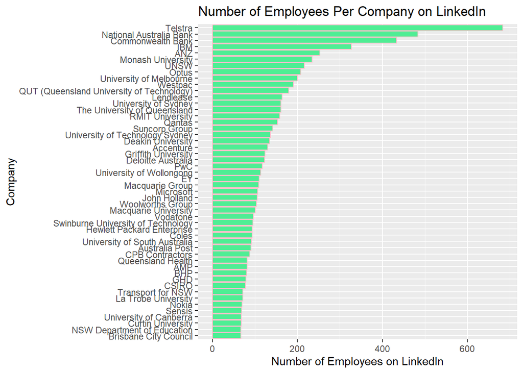

```r
# we will reorder to show the companies with the most employees at the top of the chart for readability
ggplot(top.50.companies, aes(x=reorder(companyName, n), y=n)) +
  geom_bar(stat = "identity", fill = "seagreen2", col = "pink") +
  coord_flip() +
  labs(x = "Company", y = "Number of Employees on LinkedIn", title = "Number of Employees Per Company on LinkedIn")
```

Telstra has the most employees on LinkedIn by a good amount. We start by checking how many observations we have and seeing how many of these individuals have at least 500 connections.

```r
dim(df)
```

```
## [1] 39537    27
```

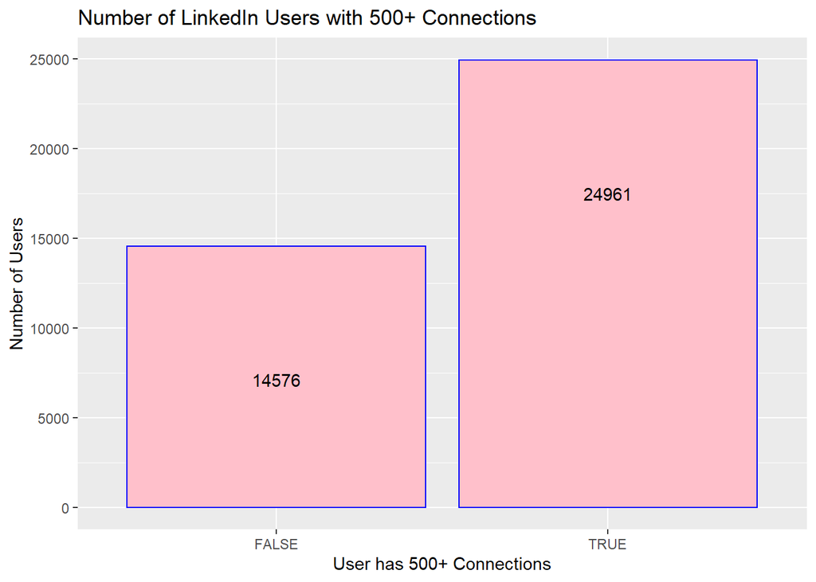

```r
at.least.500c <- df %>%
  count(connectionsCount >= 500)

ggplot(as.data.frame(at.least.500c), aes(`connectionsCount >= 500`, n, label = n)) +
  geom_bar(stat = "identity", col = "blue", fill = "pink") +
  labs(x = "User has 500+ Connections", y= "Number of Users", title = "Number of LinkedIn Users with 500+ Connections") +
  geom_text(hjust = 0.5, vjust = 10.5)
```

Another area we may be interested in is the age distribution of LinkedIn members.

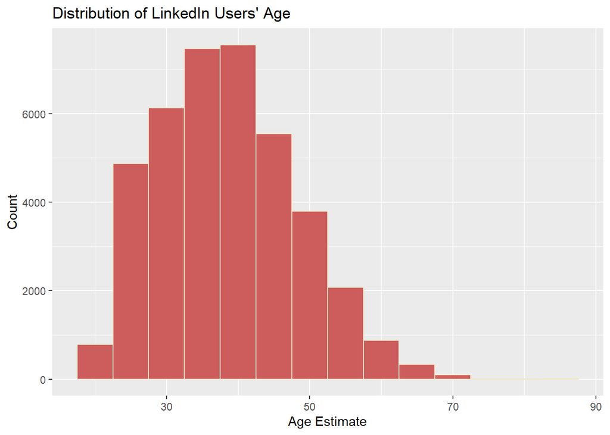

```r
ggplot(df, aes(ageEstimate)) +
  geom_histogram(col = "cornsilk2", fill = "indianred", binwidth = 5) +
  labs(title = "Distribution of LinkedIn Users' Age", x = "Age Estimate", y = "Count")
```

We see that LinkedIn users tend to be on the younger side as the data are skewed right. This makes sense since LinkedIn is a networking platform and older people are less likely to be searching for jobs. We see practically no users of age 70 or greater.

We may be interested in predicting if a user has at least 500 connections. To get an idea of how many users in our data have 500 connections or more, we make a simple table showing counts, as well as one showing percentages.

```r
df %>%
  group_by(atLeast500c) %>%
  summarize(count = n(), p = n()/nrow(df))
```

```
## # A tibble: 2 x 3
##   atLeast500c count     p
##   <lgl>       <int> <dbl>
## 1 FALSE       14576 0.369
## 2 TRUE        24961 0.631
```